fossil

# Filtering, FDR and power, dug back up.

47 results: 6 exact, 7 agree, 22 partly agree, 8 inconclusive, 2 differ, 2 not attempted. The lost R scripts were rebuilt from the paper, the simulation and the leukemia analysis were run again, and every curve was laid over the authors' own vector figures.

See every result

## Fig. 1

Fig. 1. P-value densities of the t test (8 df) under the null and the alternative, with no filter, the fold-change filter and the variance filter, 25% removed.

Partly agrees

Published

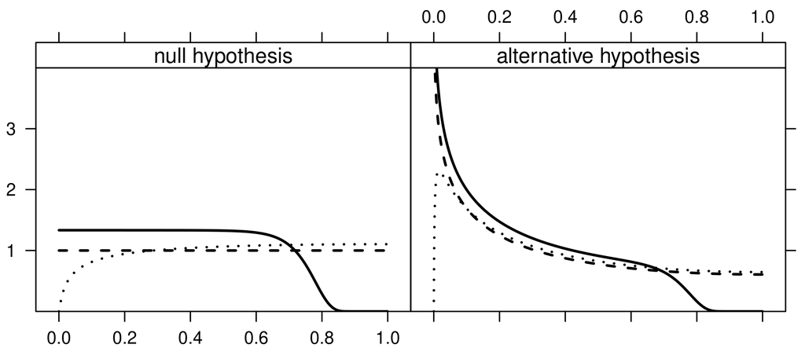

Our run

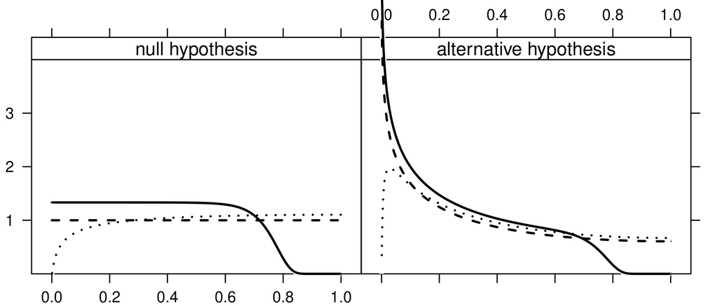

**Fig. 1, null hypothesis**

100.0% within 2 px, Agrees

**Fig. 1, alternative hypothesis**

92.0% within 2 px, Partly agrees

The no-filter and fold-change curves match the published ones within 0.002 for p from 0.01 (0.004 below); the variance-filter curve does not: ours removes more small p-values (published 2.00 against ours 1.33 at p = 0.005; up to 0.71 apart, 0.54 for p from 0.01).

## Fig. 2

Fig. 2. Fold change, signal and variance of one simulated data set: all features (bars), null (blue) and non-null (red) features, and the deciles.

Inconclusive

Published

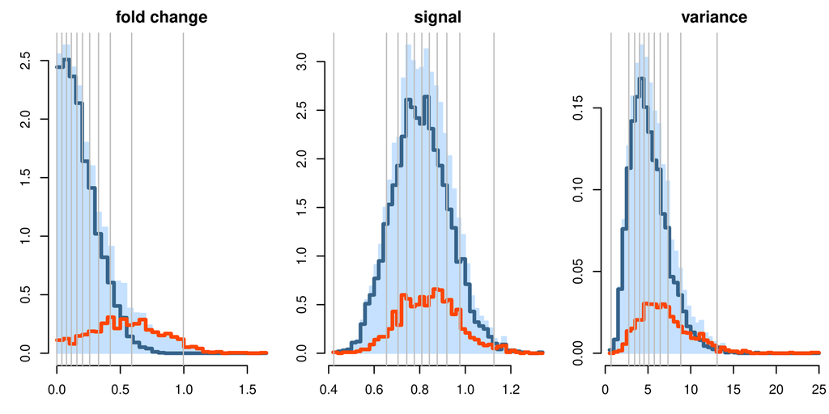

Our run

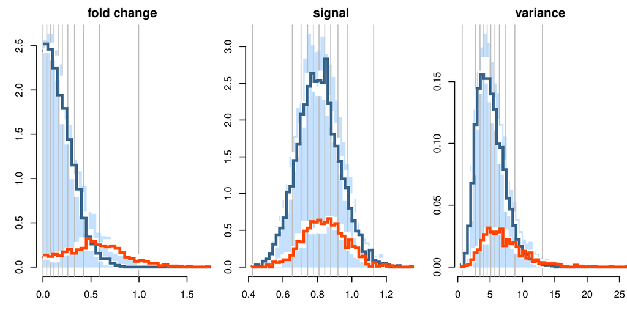

**Fig. 2, fold change**

72.5% within 2 px, Partly agrees

**Fig. 2, signal**

64.5% within 2 px, Partly agrees

**Fig. 2, variance**

80.2% within 2 px, Inconclusive

One simulated data set 'chosen at random'; its seed is not given, so the histograms differ by sampling noise. The deciles from 10% to 90% agree within 2% (the variance median 5.17 against 5.10).

## Fig. 3

Fig. 3. Mean proportion of null features left in against the fraction filtered out, for the fold-change, signal, variance, best and random filters.

Agrees

Published

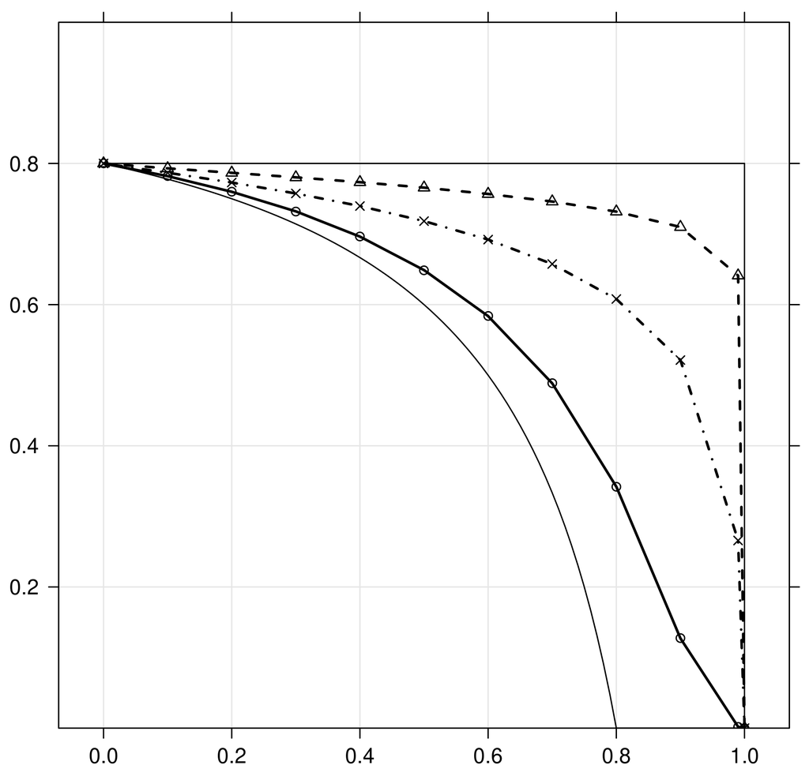

Our run

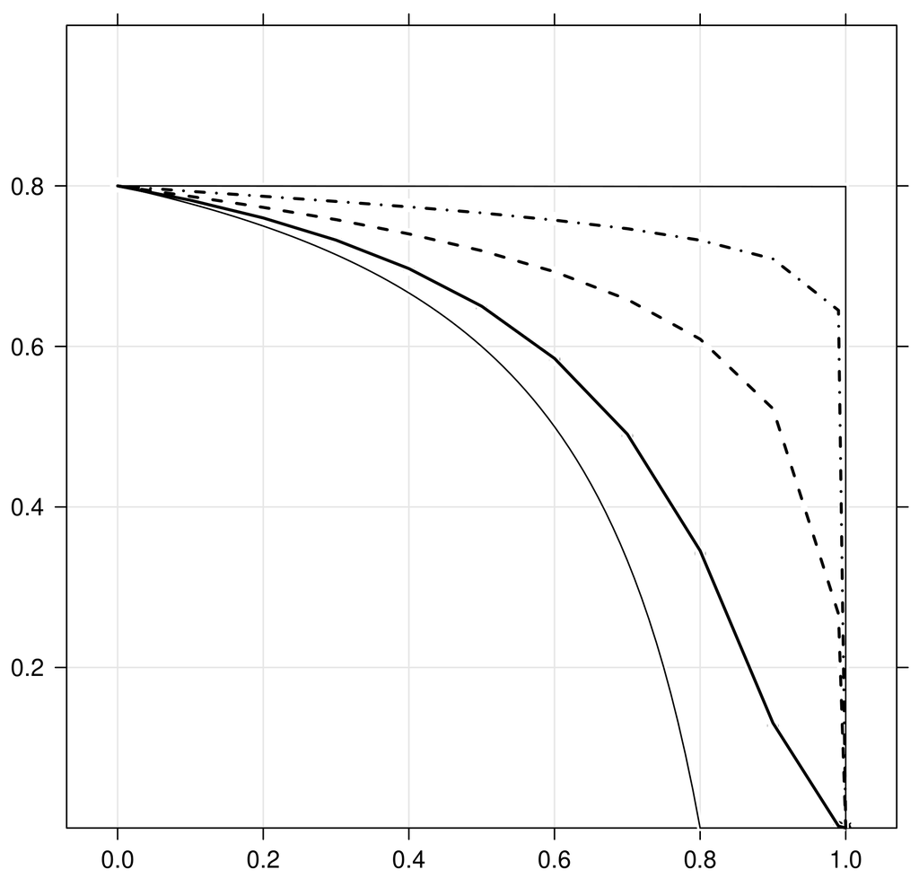

**Fig. 3**

98.8% within 2 px, Agrees

## Fig. 4

Fig. 4. Mean achieved FDR at 5% against the fraction filtered out, for BH, aBH, BY and q-value.

Partly agrees

Published

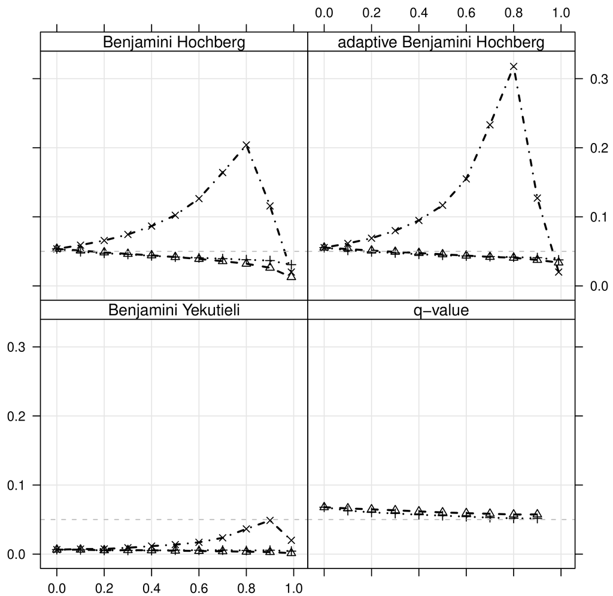

Our run

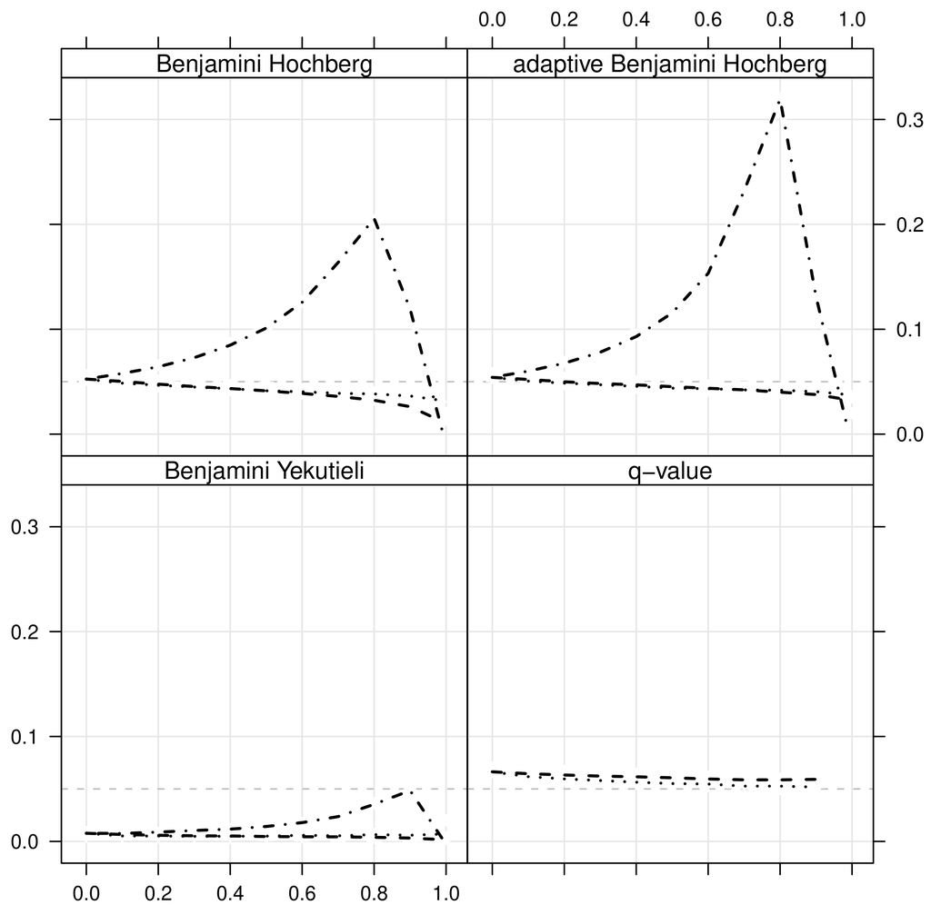

**Fig. 4, Benjamini-Hochberg**

92.3% within 2 px, Partly agrees

**Fig. 4, adaptive BH**

92.7% within 2 px, Partly agrees

**Fig. 4, Benjamini-Yekutieli**

93.2% within 2 px, Partly agrees

**Fig. 4, q-value**

95.2% within 2 px, Agrees

Every point but the last lies within 0.004 of the published curve. The paper draws the fold-change filter at x = 0.99 at 0.0201 for BH, aBH and BY alike (one false positive among the 50 features left), while its own Fig. 3 puts pi0 at 0.0019 there (0.1 null features); ours is 0.0024.

## Fig. 5

Fig. 5. Mean power against the BH level, one curve per fraction filtered out (0 to 0.9 and 0.99).

Partly agrees

Published

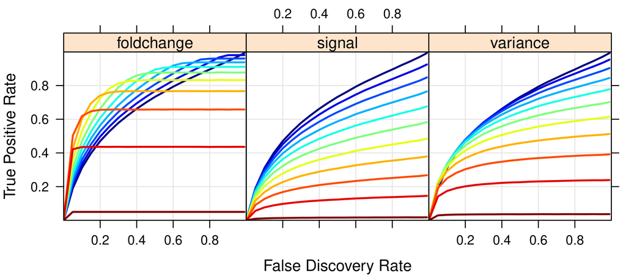

Our run

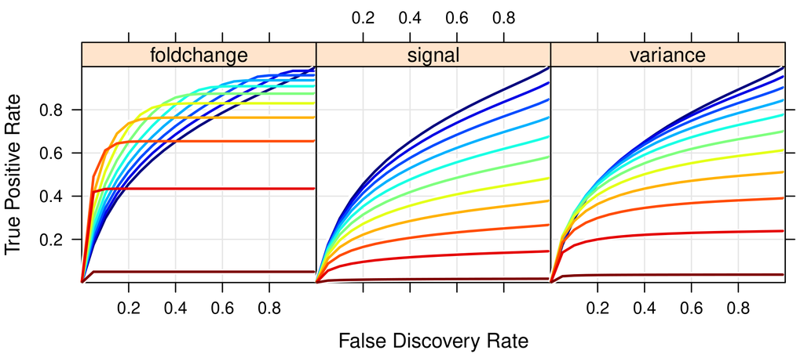

**Fig. 5, fold change**

93.4% within 2 px, Partly agrees

**Fig. 5, signal**

91.0% within 2 px, Partly agrees

**Fig. 5, variance**

94.5% within 2 px, Partly agrees

The power curves lie within about 0.016 of the published ones, more than the Monte Carlo error (about 0.001) allows; the achieved FDR of the same runs (Fig. 4) matches within 0.004.

## Fig. 6

Fig. 6. The FDR-bias test for the fold-change filter on one data set: per-permutation p-values, achieved FDR of BH, aBH, BY and Bonferroni, and the test's p-values.

Inconclusive

Published

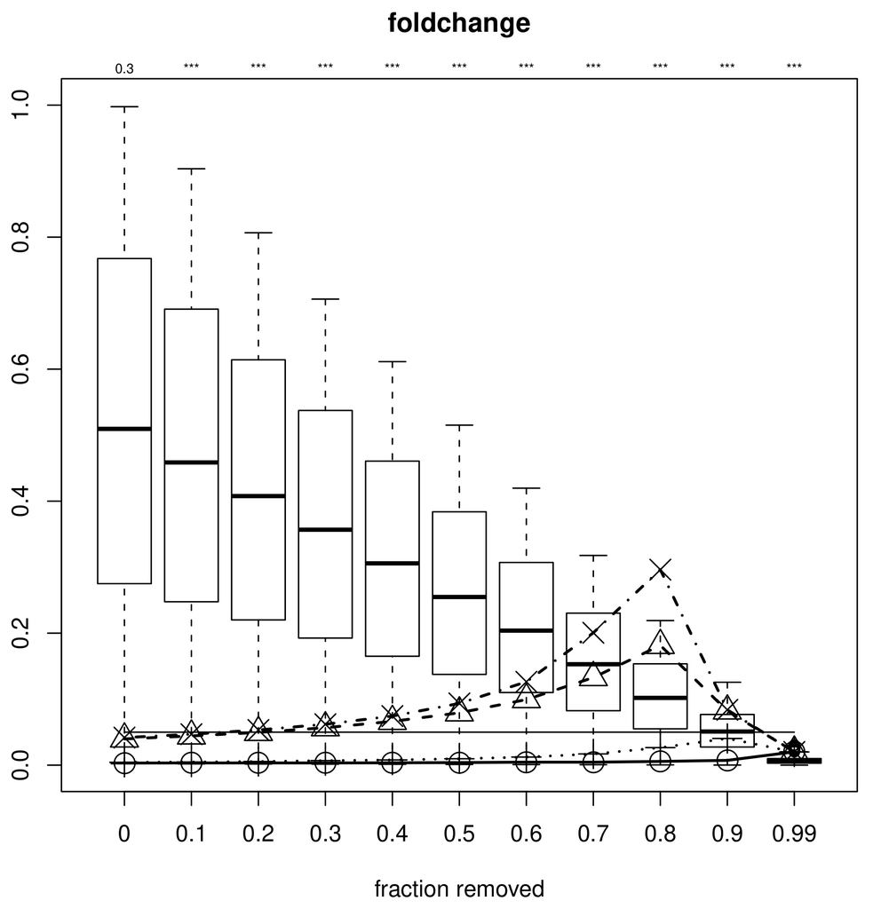

Our run

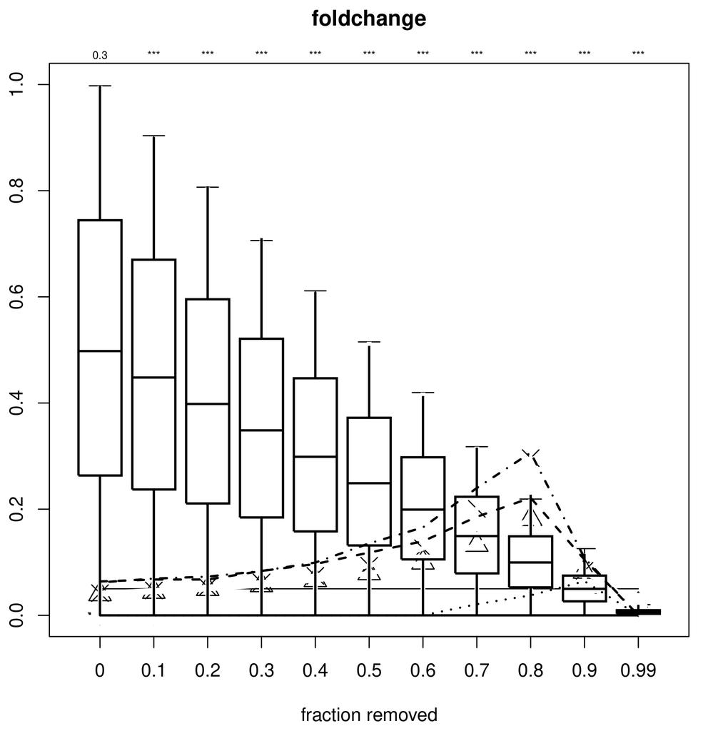

**Fig. 6**

62.2% within 2 px, Inconclusive

**Fig. 6, the test's p-values above the boxes**

10 of 11 values, Partly agrees

With no noise term the box medians come back (0.50, 0.45, ..., 0.01 against 0.51, 0.46, ..., 0.01), but our quartiles sit about 3% low and the FDR lines are of another data set; the same boxes 5% larger score as well as ours. At x = 0 nothing is filtered and the test's p-value is uniform over data sets: the paper's 0.3 and our 0.6 both say 'no bias'. The ten '***' come back.

## Fig. 7

Fig. 7. Leukemia data (TEL-AML1 against hyperdiploid): achieved FDR at BH 5% against the fraction filtered out, for random subsets of 8, 16 and 24 per group.

Inconclusive

Published

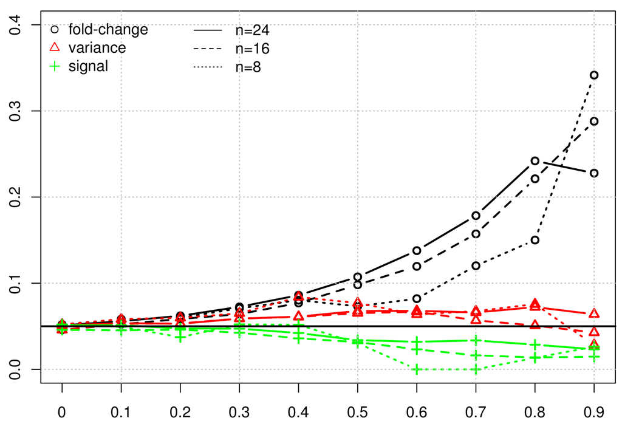

Our run

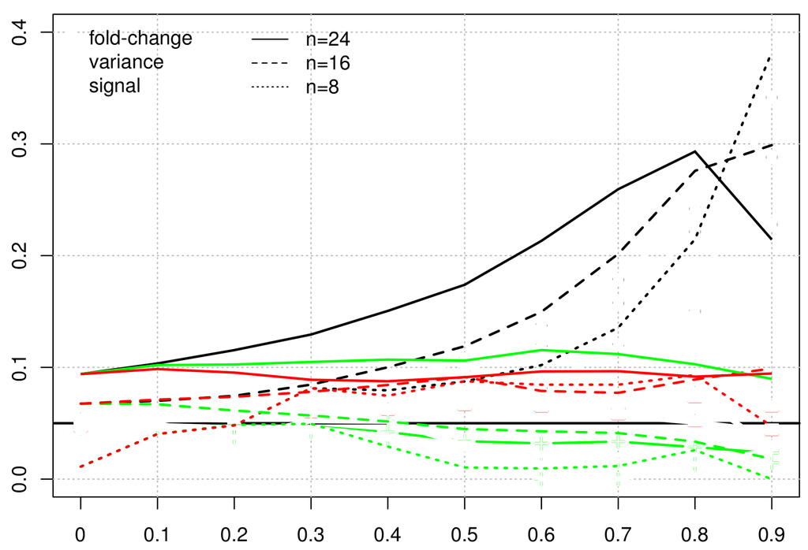

**Fig. 7**

12.9% within 2 px, Inconclusive

One random subset of each size, as in the paper, whose draws are not given. 71 of the 90 published points lie within the range of our 20 other subsets.

## Figure S2

Figure S2. Mean power at 5% against the fraction filtered out, for BH, aBH, BY and q-value.

Partly agrees

Published

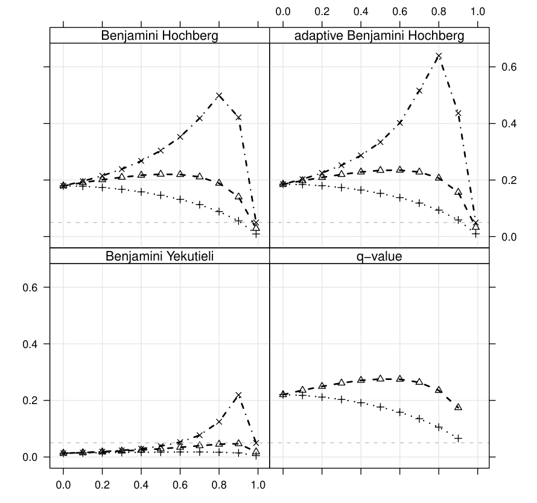

Our run

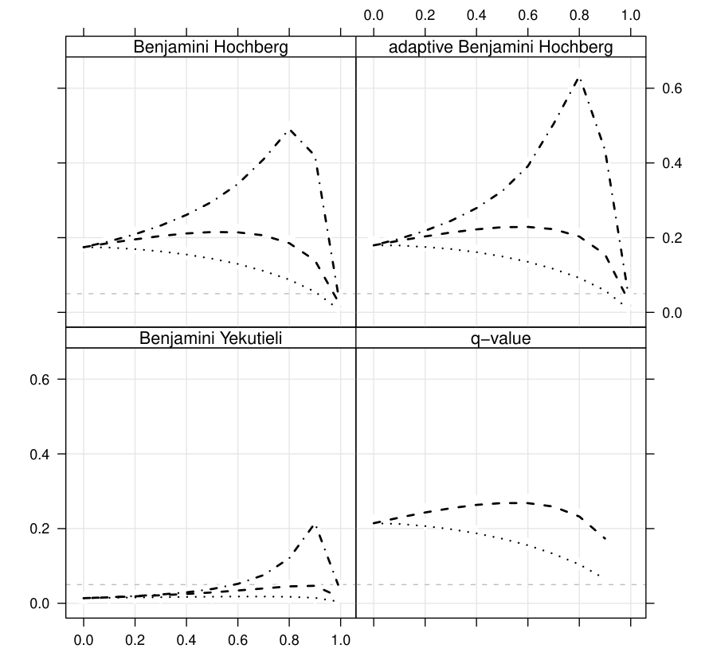

**Figure S2, Benjamini-Hochberg**

76.4% within 2 px, Partly agrees

**Figure S2, adaptive BH**

75.4% within 2 px, Partly agrees

**Figure S2, Benjamini-Yekutieli**

99.7% within 2 px, Partly agrees

**Figure S2, q-value**

68.6% within 2 px, Partly agrees

The power curves lie within about 0.016 of the published ones, more than the Monte Carlo error (about 0.001) allows; the achieved FDR of the same runs (Fig. 4) matches within 0.004. BY power is about 0.02, so 5% more or less moves the curve by less than the 2 px tolerance: the score (99.7%) cannot reach a mark above the near-miss controls (99.5%).

## Figure S3

Figure S3. Mean power against mean achieved FDR over BH levels, one curve per fraction filtered out.

Partly agrees

Published

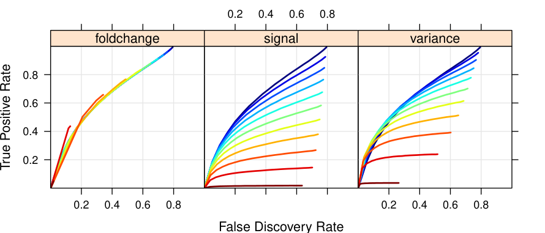

Our run

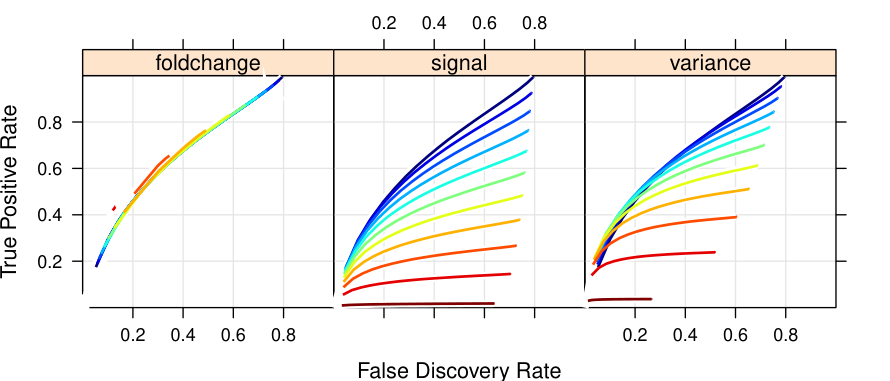

**Figure S3, fold change**

69.9% within 2 px, Partly agrees

**Figure S3, signal**

97.2% within 2 px, Agrees

**Figure S3, variance**

96.1% within 2 px, Agrees

The power curves lie within about 0.016 of the published ones, more than the Monte Carlo error (about 0.001) allows; the achieved FDR of the same runs (Fig. 4) matches within 0.004.

## Figure S4

Figure S4. The FDR-bias test for the variance, signal and fold-change filters on one data set.

Differs

Published

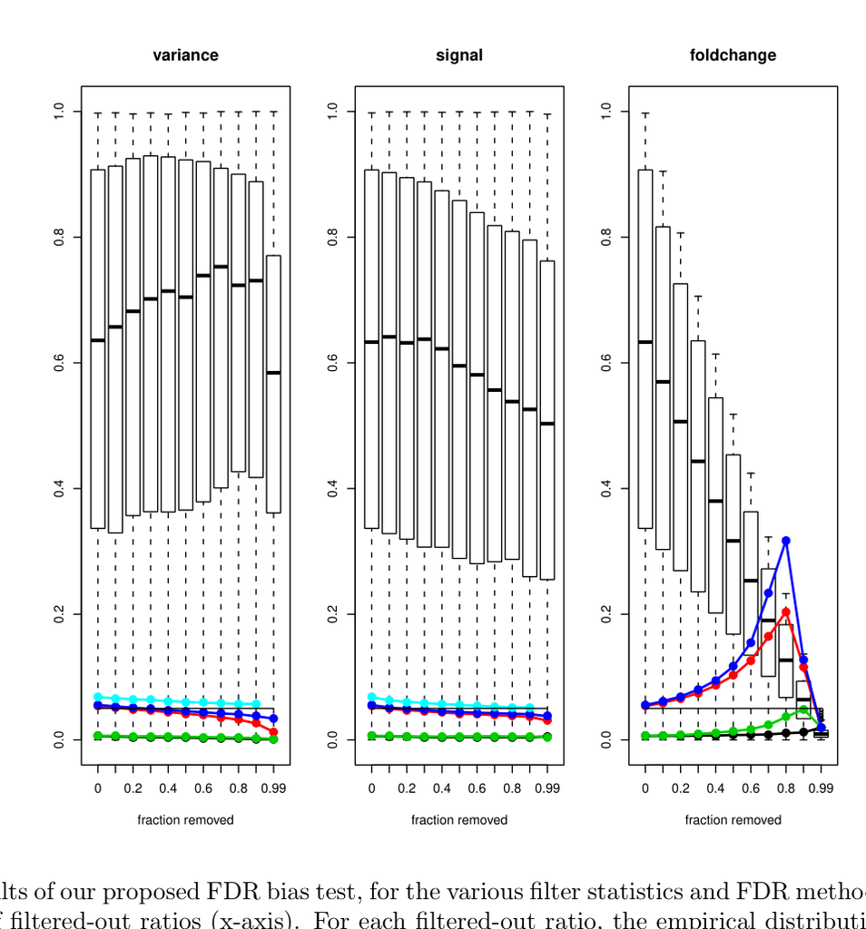

Our run

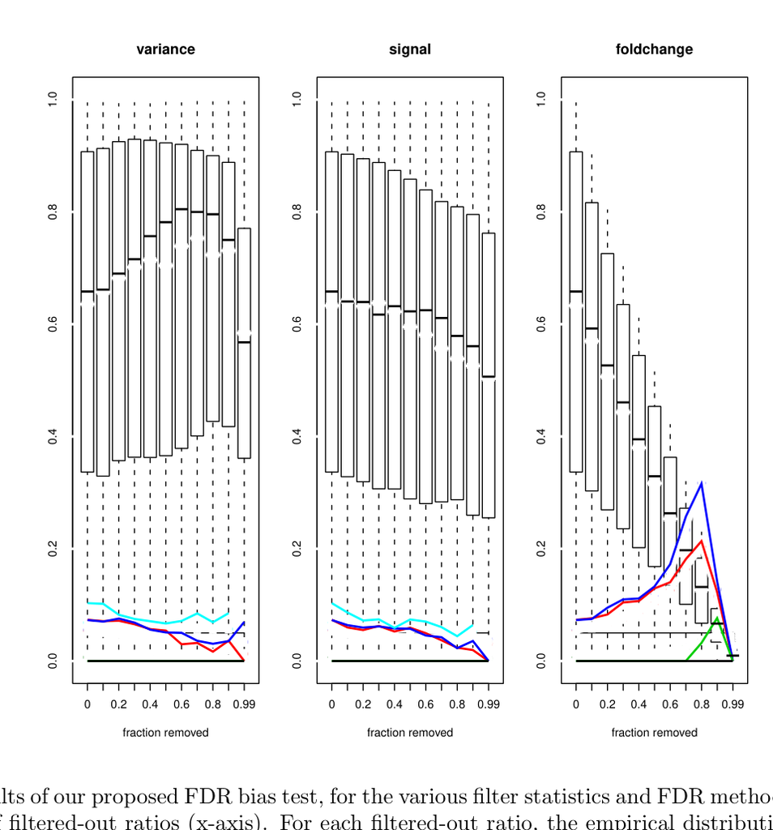

**Figure S4, variance**

25.0% within 2 px, Differs

**Figure S4, signal**

30.2% within 2 px, Inconclusive

**Figure S4, fold change**

31.5% within 2 px, Inconclusive

One data set and one set of permutations, neither given. The box medians follow the published ones; the achieved-FDR lines of a single data set differ by sampling noise and dominate the score.

## Figure S5

Figure S5. Leukemia data: power at BH 5% against the fraction filtered out.

Differs

Published

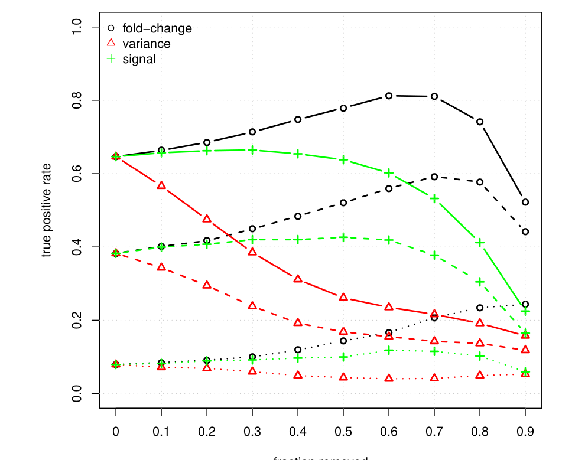

Our run

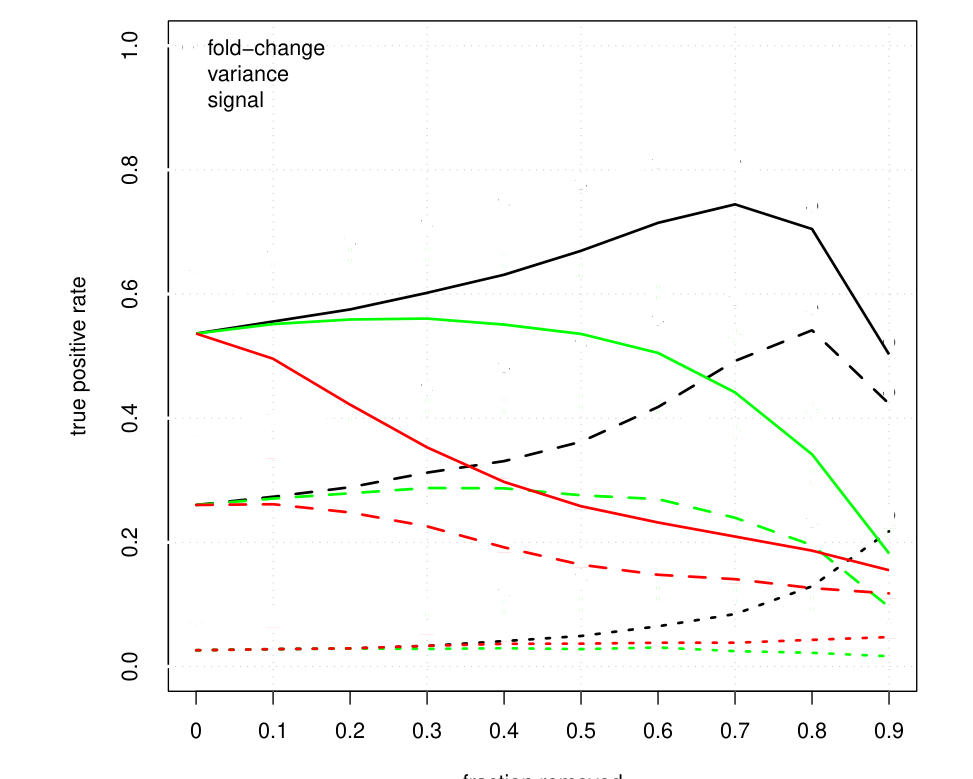

**Figure S5**

12.4% within 2 px, Differs

The published power is higher than ours at every size (n = 24, x = 0: 0.65 against 0.48 over 20 draws), while the achieved FDR (Fig. 7) is not; only 16 of 90 published points lie within the range of our 20 subsets.

## Figure S6

Figure S6. Wilcoxon rank-sum test with BH: achieved FDR and power against the fraction filtered out.

Inconclusive

Published

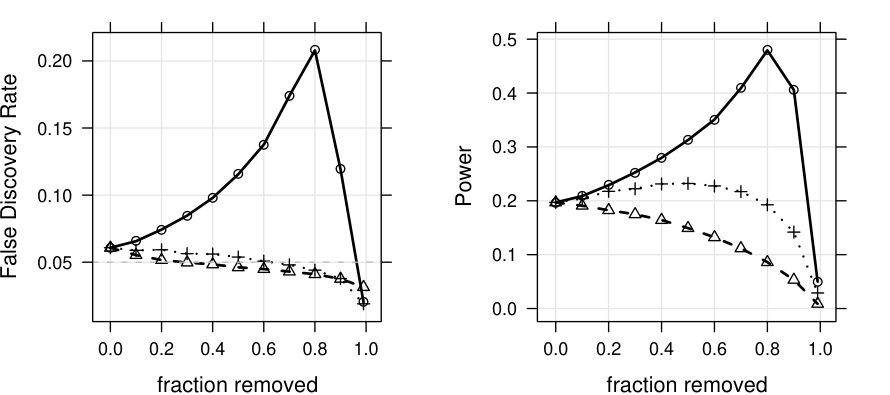

Our run

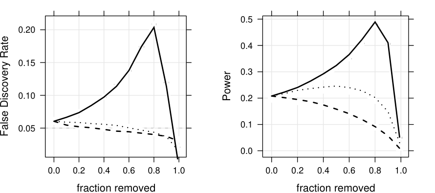

**Figure S6, achieved FDR**

92.5% within 2 px, Partly agrees

**Figure S6, power**

38.3% within 2 px, Inconclusive

Every point but the last lies within 0.006 of the published curve; the fold-change point at x = 0.99 is drawn at 0.020, as in Fig. 4. Our Wilcoxon power is about 5% above the published at every point (the x0.95 control scores 89%, ours 38%), while the achieved FDR of the same runs matches.

## Figure S8

Figure S8. Achieved FDR with filtering before (25, 50%) or after (10, 20%) the BH correction against no filtering: least-squares lines over 100 data sets.

Inconclusive

Published

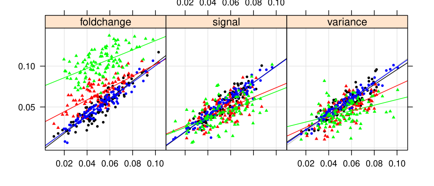

Our run

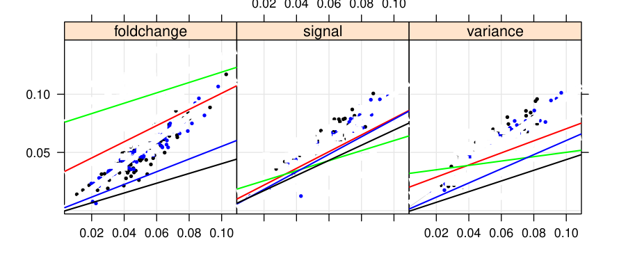

**Figure S8, fold change (achieved FDR)**

28.4% within 2 px, Partly agrees

**Figure S8, signal (achieved FDR)**

39.9% within 2 px, Partly agrees

**Figure S8, variance (achieved FDR)**

15.1% within 2 px, Inconclusive

How situation C filters the selected list is not stated. Dropping the 10 or 20% of the selected list with the smallest statistic halves the FDR of the fold-change filter (0.054 to 0.030), where the paper's lines stay on x = y; cutting at the quantile over all features keeps the FDR but loses no power, where the paper's power falls 7 to 23%.

## Figure S9

Figure S9. Power with filtering before or after the BH correction against no filtering: least-squares lines.

Inconclusive

Published

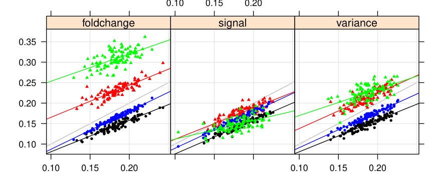

Our run

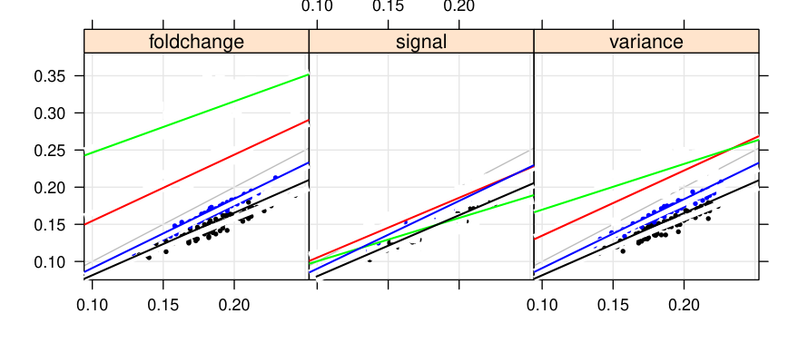

**Figure S9, fold change (power)**

23.0% within 2 px, Inconclusive

**Figure S9, signal (power)**

55.2% within 2 px, Partly agrees

**Figure S9, variance (power)**

59.7% within 2 px, Partly agrees

How situation C filters the selected list is not stated. Dropping the 10 or 20% of the selected list with the smallest statistic halves the FDR of the fold-change filter (0.054 to 0.030), where the paper's lines stay on x = y; cutting at the quantile over all features keeps the FDR but loses no power, where the paper's power falls 7 to 23%.

## Every result

Every figure panel and claim of the paper and its Additional File 1. A figure panel agrees when 95% of the published ink lies within 2 px of ours and ours of it, at 300 dpi on the published panel's own axes, and no wrong or near-miss version scores as well.

Result

Verdict

Measure

Why

Fig. 1, null hypothesis

Agrees

100.0% within 2 px

Fig. 1, alternative hypothesis

Partly agrees

92.0% within 2 px

The no-filter and fold-change curves match the published ones within 0.002 for p from 0.01 (0.004 below); the variance-filter curve does not: ours removes more small p-values (published 2.00 against ours 1.33 at p = 0.005; up to 0.71 apart, 0.54 for p from 0.01).

Fig. 2, fold change

Partly agrees

72.5% within 2 px

One simulated data set 'chosen at random'; its seed is not given, so the histograms differ by sampling noise. The deciles from 10% to 90% agree within 2% (the variance median 5.17 against 5.10).

Fig. 2, signal

Partly agrees

64.5% within 2 px

One simulated data set 'chosen at random'; its seed is not given, so the histograms differ by sampling noise. The deciles from 10% to 90% agree within 2% (the variance median 5.17 against 5.10).

Fig. 2, variance

Inconclusive

80.2% within 2 px

One simulated data set 'chosen at random'; its seed is not given, so the histograms differ by sampling noise. The deciles from 10% to 90% agree within 2% (the variance median 5.17 against 5.10).

Fig. 3

Agrees

98.8% within 2 px

Fig. 4, Benjamini-Hochberg

Partly agrees

92.3% within 2 px

Every point but the last lies within 0.004 of the published curve. The paper draws the fold-change filter at x = 0.99 at 0.0201 for BH, aBH and BY alike (one false positive among the 50 features left), while its own Fig. 3 puts pi0 at 0.0019 there (0.1 null features); ours is 0.0024.

Fig. 4, adaptive BH

Partly agrees

92.7% within 2 px

Every point but the last lies within 0.004 of the published curve. The paper draws the fold-change filter at x = 0.99 at 0.0201 for BH, aBH and BY alike (one false positive among the 50 features left), while its own Fig. 3 puts pi0 at 0.0019 there (0.1 null features); ours is 0.0024.

Fig. 4, Benjamini-Yekutieli

Partly agrees

93.2% within 2 px

Every point but the last lies within 0.004 of the published curve. The paper draws the fold-change filter at x = 0.99 at 0.0201 for BH, aBH and BY alike (one false positive among the 50 features left), while its own Fig. 3 puts pi0 at 0.0019 there (0.1 null features); ours is 0.0024.

Fig. 4, q-value

Agrees

95.2% within 2 px

Fig. 5, fold change

Partly agrees

93.4% within 2 px

The power curves lie within about 0.016 of the published ones, more than the Monte Carlo error (about 0.001) allows; the achieved FDR of the same runs (Fig. 4) matches within 0.004.

Fig. 5, signal

Partly agrees

91.0% within 2 px

The power curves lie within about 0.016 of the published ones, more than the Monte Carlo error (about 0.001) allows; the achieved FDR of the same runs (Fig. 4) matches within 0.004.

Fig. 5, variance

Partly agrees

94.5% within 2 px

The power curves lie within about 0.016 of the published ones, more than the Monte Carlo error (about 0.001) allows; the achieved FDR of the same runs (Fig. 4) matches within 0.004.

Fig. 6

Inconclusive

62.2% within 2 px

With no noise term the box medians come back (0.50, 0.45, ..., 0.01 against 0.51, 0.46, ..., 0.01), but our quartiles sit about 3% low and the FDR lines are of another data set; the same boxes 5% larger score as well as ours.

Fig. 7

Inconclusive

12.9% within 2 px

One random subset of each size, as in the paper, whose draws are not given. 71 of the 90 published points lie within the range of our 20 other subsets.

Figure S1 (scatter plots of the filter statistics)

Not attempted

A raster scatter plot of one unseeded data set: its points cannot be read back, and the claim it illustrates (little association between the filter statistics) has no number to compare.

Figure S2, Benjamini-Hochberg

Partly agrees

76.4% within 2 px

The power curves lie within about 0.016 of the published ones, more than the Monte Carlo error (about 0.001) allows; the achieved FDR of the same runs (Fig. 4) matches within 0.004.

Figure S2, adaptive BH

Partly agrees

75.4% within 2 px

The power curves lie within about 0.016 of the published ones, more than the Monte Carlo error (about 0.001) allows; the achieved FDR of the same runs (Fig. 4) matches within 0.004.

Figure S2, Benjamini-Yekutieli

Partly agrees

99.7% within 2 px

BY power is about 0.02, so 5% more or less moves the curve by less than the 2 px tolerance: the score (99.7%) cannot reach a mark above the near-miss controls (99.5%).

Figure S2, q-value

Partly agrees

68.6% within 2 px

The power curves lie within about 0.016 of the published ones, more than the Monte Carlo error (about 0.001) allows; the achieved FDR of the same runs (Fig. 4) matches within 0.004.

Figure S3, fold change

Partly agrees

69.9% within 2 px

The power curves lie within about 0.016 of the published ones, more than the Monte Carlo error (about 0.001) allows; the achieved FDR of the same runs (Fig. 4) matches within 0.004.

Figure S3, signal

Agrees

97.2% within 2 px

Figure S3, variance

Agrees

96.1% within 2 px

Figure S4, variance

Differs

25.0% within 2 px

One data set and one set of permutations, neither given. The box medians follow the published ones; the achieved-FDR lines of a single data set differ by sampling noise and dominate the score.

Figure S4, signal

Inconclusive

30.2% within 2 px

One data set and one set of permutations, neither given. The box medians follow the published ones; the achieved-FDR lines of a single data set differ by sampling noise and dominate the score.

Figure S4, fold change

Inconclusive

31.5% within 2 px

One data set and one set of permutations, neither given. The box medians follow the published ones; the achieved-FDR lines of a single data set differ by sampling noise and dominate the score.

Figure S5

Differs

12.4% within 2 px

The published power is higher than ours at every size (n = 24, x = 0: 0.65 against 0.48 over 20 draws), while the achieved FDR (Fig. 7) is not; only 16 of 90 published points lie within the range of our 20 subsets.

Figure S6, achieved FDR

Partly agrees

92.5% within 2 px

Every point but the last lies within 0.006 of the published curve; the fold-change point at x = 0.99 is drawn at 0.020, as in Fig. 4.

Figure S6, power

Inconclusive

38.3% within 2 px

Our Wilcoxon power is about 5% above the published at every point (the x0.95 control scores 89%, ours 38%), while the achieved FDR of the same runs matches.

Figure S7 (bootFDR and permFDR)

Not attempted

Neither the bootFDR (Dudoit et al.) nor the permFDR (Reiner et al.) settings, nor the number of data sets, are given; the figure would show our choice of them.

Figure S8, fold change (achieved FDR)

Partly agrees

28.4% within 2 px

How situation C filters the selected list is not stated. Dropping the 10 or 20% of the selected list with the smallest statistic halves the FDR of the fold-change filter (0.054 to 0.030), where the paper's lines stay on x = y; cutting at the quantile over all features keeps the FDR but loses no power, where the paper's power falls 7 to 23%.

Figure S8, signal (achieved FDR)

Partly agrees

39.9% within 2 px

How situation C filters the selected list is not stated. Dropping the 10 or 20% of the selected list with the smallest statistic halves the FDR of the fold-change filter (0.054 to 0.030), where the paper's lines stay on x = y; cutting at the quantile over all features keeps the FDR but loses no power, where the paper's power falls 7 to 23%.

Figure S8, variance (achieved FDR)

Inconclusive

15.1% within 2 px

How situation C filters the selected list is not stated. Dropping the 10 or 20% of the selected list with the smallest statistic halves the FDR of the fold-change filter (0.054 to 0.030), where the paper's lines stay on x = y; cutting at the quantile over all features keeps the FDR but loses no power, where the paper's power falls 7 to 23%.

Figure S9, fold change (power)

Inconclusive

23.0% within 2 px

How situation C filters the selected list is not stated. Dropping the 10 or 20% of the selected list with the smallest statistic halves the FDR of the fold-change filter (0.054 to 0.030), where the paper's lines stay on x = y; cutting at the quantile over all features keeps the FDR but loses no power, where the paper's power falls 7 to 23%.

Figure S9, signal (power)

Partly agrees

55.2% within 2 px

How situation C filters the selected list is not stated. Dropping the 10 or 20% of the selected list with the smallest statistic halves the FDR of the fold-change filter (0.054 to 0.030), where the paper's lines stay on x = y; cutting at the quantile over all features keeps the FDR but loses no power, where the paper's power falls 7 to 23%.

Figure S9, variance (power)

Partly agrees

59.7% within 2 px

How situation C filters the selected list is not stated. Dropping the 10 or 20% of the selected list with the smallest statistic halves the FDR of the fold-change filter (0.054 to 0.030), where the paper's lines stay on x = y; cutting at the quantile over all features keeps the FDR but loses no power, where the paper's power falls 7 to 23%.

Results: achieved FDR after filtering (Fig. 4)

Exact

6 of 6 values

- BH: the fold-change filter raises the achieved FDR more the more is removed (x = 0, 0.2, ..., 0.8): paper yes, ours **yes**
- aBH: the same: paper yes, ours **yes**
- BH: the variance and signal filters do not raise the achieved FDR (by 0.005 or more, x up to 0.9): paper yes, ours **yes**
- aBH is above 5% with no filtering: paper yes, ours **yes**
- q-value is above 5% with no filtering: paper yes, ours **yes**
- BY is below 5% over the entire range (all filters, x up to 0.99): paper yes, ours **yes**

Results: filters ranked by pi0 (text and Fig. 3 caption)

Exact

3 of 4 values

- fold change is the best realistic filter (lowest pi0 at every x from 0.1 to 0.99): paper yes, ours **yes**
- text: signal is the worst realistic filter (highest pi0 at every x): paper yes, ours **yes**
- text: signal is only slightly better than random (pi0 below 0.8 at every x): paper yes, ours **yes**
- caption: from bottom to top, fold change, signal, variance (signal below variance at every x): paper yes, ours **no**

Results: power against BH level (Fig. 5)

Exact

1 of 2 values

- signal and variance filters always give less power after filtering (every BH level, every x): paper yes, ours **no**
- fold change gives more power for BH levels up to 0.1 and x up to 0.5: paper yes, ours **yes**

Results: the FDR-bias test (Figs 6 and S4)

Exact

4 of 4 values

- fold change: the test rejects even at 10% removed (Fig. S4 data set): paper yes, ours **yes**
- fold change: the same on the Fig. 6 data set: paper yes, ours **yes**
- signal: null p-values approximately uniform at every x (no p below 0.001): paper yes, ours **yes**
- variance: the same: paper yes, ours **yes**

Fig. 6, the test's p-values above the boxes

Partly agrees

10 of 11 values

- x = 0: paper 0.3, ours **0.6**
- x = 0.1: paper ***, ours ***
- x = 0.2: paper ***, ours ***
- x = 0.3: paper ***, ours ***
- x = 0.4: paper ***, ours ***
- x = 0.5: paper ***, ours ***
- x = 0.6: paper ***, ours ***
- x = 0.7: paper ***, ours ***
- x = 0.8: paper ***, ours ***
- x = 0.9: paper ***, ours ***
- x = 0.99: paper ***, ours ***

At x = 0 nothing is filtered and the test's p-value is uniform over data sets: the paper's 0.3 and our 0.6 both say 'no bias'. The ten '***' come back.

Results: childhood leukemia (Figs 7 and S5)

Partly agrees

3 of 4 values

- signal and variance: achieved FDR stays around 5% (mean over x = 0 to 0.8 within 0.025 of 0.05, every size): paper yes, ours **no**
- fold change: achieved FDR rises with x (x = 0.8 above x = 0 by 0.05 or more, every size): paper yes, ours **yes**
- power rises with sample size (8 < 16 < 24 at x = 0): paper yes, ours **yes**
- fold change raises power; signal and variance have no or the opposite effect (gain below 0.02; x = 0.5 against 0, every size): paper yes, ours **yes**

On our subset of 24 per group the signal and variance filters' achieved FDR averages about 0.10, not about 5%: the subset is one random draw (the paper's figure satisfies the rule).

Discussion: Wilcoxon test (Figure S6)

Exact

1 of 1 values

- Wilcoxon FDR and power curves very similar to the t test's (differ by less than 0.05): paper yes, ours **yes**

Additional File 1, section 13: filtering after the correction (Figures S8, S9)

Partly agrees

2 of 4 values

- filtering after the correction (10, 20%) does not bias the FDR (mean within 0.01 of no filtering, every filter): paper yes, ours **no**
- filtering after the correction loses a little power (every filter): paper yes, ours **yes**
- fold change before the correction (25, 50%) biases the FDR (mean above no filtering by 0.01 or more): paper yes, ours **yes**
- fold change is the only filter that gains power when used before the correction: paper yes, ours **no**

How situation C filters the selected list is not stated. Dropping the 10 or 20% of the selected list with the smallest statistic halves the FDR of the fold-change filter (0.054 to 0.030), where the paper's lines stay on x = y; cutting at the quantile over all features keeps the FDR but loses no power, where the paper's power falls 7 to 23%.

Numbers in the text recomputed from the paper's own statements

Exact

1 of 3 values

- non-null features: m (1 - pi0) = 5000 x 0.2: paper 4000, ours **1000**
- Querec et al.: 7 false of 65 genes, as a percentage: paper 11, ours **11**
- Querec et al.: 7 false of 33 tested genes, as a percentage: paper 20, ours **21**

Claims recomputed from the values of the paper's own figures

Agrees

R package filterfdr and its tutorial

Agrees

The main finding holds: the fold-change filter biases the FDR and raises power, and the signal and variance filters do not bias it. Three sentences overstate the paper's own figures, and Fig. 3's caption swaps two curves; the power gaps of Figs 5, S2, S5 and S6 are open.

## What came back

**Fig. 4**

Achieved FDR for four methods within 0.004 at every point but one.

**Fig. 3**

pi0 for every filter within 0.004, once the caption's swapped labels are put back.

**Fig. 1**

The null densities exactly, and two of the three alternative curves.

**Fig. 6**

The test's box medians, from data without the noise term.

**The method**

Simulation, filters, FDR-bias test and p-value densities as the R package filterfdr.

## What stayed buried

The main finding holds: the fold-change filter biases the FDR and raises power, and the signal and variance filters do not bias it. Three sentences overstate the paper's own figures, and Fig. 3's caption swaps two curves; the power gaps of Figs 5, S2, S5 and S6 are open.

## What we matched

How each part of the paper's method was rebuilt.

**Simulation**

**Filters**

Signal, fold change and variance, cut at their empirical quantiles.

**Corrections**

BH, BY, multtest's two-stage aBH and qvalue, at 5% and at 21 levels.

**Bias test**

Rows permuted one by one, BH-based KS per permutation, then a one-sided KS over 1000 permutations.

**Leukemia**

GSE13425, 44 TEL-AML1 against 44 hyperdiploid, limma, truth from all 88.